# Personalized Marketing - Customer Analysis For Customer Behavior and Predicting The Likelihood Of Marketing Engagement

Aditya Phulallwar

2022-06-19

# Dataset Intro:

The IBM Watson Marketing Customer Value Data can be used analyze all relevant customer data and develop focused customer retention programs.Understand customer demographics and buying behavior. Use predictive analytics to analyze the most profitable customers and how they interact. Take targeted actions to increase profitable customer response, retention, and growth.

avialable at [link](https://www.kaggle.com/datasets/pankajjsh06/ibm-watson-marketing-customer-value-data?resource=download&select=WA_Fn-UseC_-Marketing-Customer-Value-Analysis.csv)

| Customer | State | Customer.Lifetime.Value | Response | Coverage | Education | Effective.To.Date | EmploymentStatus | Gender | Income | Location.Code | Marital.Status | Monthly.Premium.Auto | Months.Since.Last.Claim | Months.Since.Policy.Inception | Number.of.Open.Complaints | Number.of.Policies | Policy.Type | Policy | Renew.Offer.Type | Sales.Channel | Total.Claim.Amount | Vehicle.Class | Vehicle.Size |
| --- | --- | --- | --- | --- | --- | --- | --- | --- | --- | --- | --- | --- | --- | --- | --- | --- | --- | --- | --- | --- | --- | --- | --- |
| BU79786 | Washington | 2763.519 | No | Basic | Bachelor | 2/24/11 | Employed | F | 56274 | Suburban | Married | 69 | 32 | 5 | 0 | 1 | Corporate Auto | Corporate L3 | Offer1 | Agent | 384.8111 | Two-Door Car | Medsize |
| QZ44356 | Arizona | 6979.536 | No | Extended | Bachelor | 1/31/11 | Unemployed | F | 0 | Suburban | Single | 94 | 13 | 42 | 0 | 8 | Personal Auto | Personal L3 | Offer3 | Agent | 1131.4649 | Four-Door Car | Medsize |
| AI49188 | Nevada | 12887.432 | No | Premium | Bachelor | 2/19/11 | Employed | F | 48767 | Suburban | Married | 108 | 18 | 38 | 0 | 2 | Personal Auto | Personal L3 | Offer1 | Agent | 566.4722 | Two-Door Car | Medsize |
| WW63253 | California | 7645.862 | No | Basic | Bachelor | 1/20/11 | Unemployed | M | 0 | Suburban | Married | 106 | 18 | 65 | 0 | 7 | Corporate Auto | Corporate L2 | Offer1 | Call Center | 529.8813 | SUV | Medsize |
| HB64268 | Washington | 2813.693 | No | Basic | Bachelor | 2/3/11 | Employed | M | 43836 | Rural | Single | 73 | 12 | 44 | 0 | 1 | Personal Auto | Personal L1 | Offer1 | Agent | 138.1309 | Four-Door Car | Medsize |
| OC83172 | Oregon | 8256.298 | Yes | Basic | Bachelor | 1/25/11 | Employed | F | 62902 | Rural | Married | 69 | 14 | 94 | 0 | 2 | Personal Auto | Personal L3 | Offer2 | Web | 159.3830 | Two-Door Car | Medsize |

There is a column named *Response*, which contains information about whether a customer responded to the marketing efforts. Also, the *Renew.Offer.Type* and *Sales.Channel* columns represent the type of renewal offer presented to the customer and which sales channel was used to contact the customer. There are numerous other columns that represent the socio-economic backgrounds of the customers and types of insurance coverages that the customers currently have.

## Analytics on engaged customers

Analyzing how different customers behave and react to different marketing strategies

### Overall Engagement Rate

| Response | Count | EngagementRate |
| --- | --- | --- |
| No | 7826 | 85.67988 |
| Yes | 1308 | 14.32012 |

The majority of the customers did not respond to the marketing calls. As shown from the data, only 14% of the customers responded to the marketing calls.

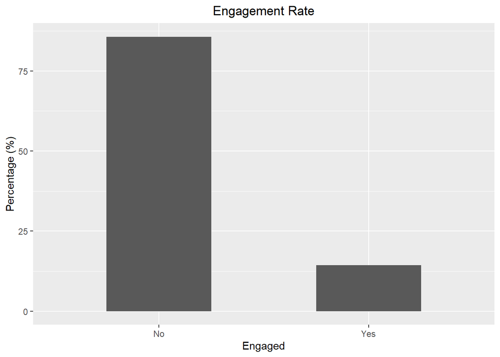

### Engagement Rates By Offer Type

Different types of offers will work differently for different customers. What types of offers worked best for the engaged customers.

| Renew.Offer.Type | Count | NumEngaged | EngagementRate |
| --- | --- | --- | --- |
| Offer1 | 3752 | 594 | 15.831556 |
| Offer2 | 2926 | 684 | 23.376623 |
| Offer3 | 1432 | 30 | 2.094972 |
| Offer4 | 1024 | 0 | 0.000000 |

*Offer 2* had the highest engagement rate among the customers.

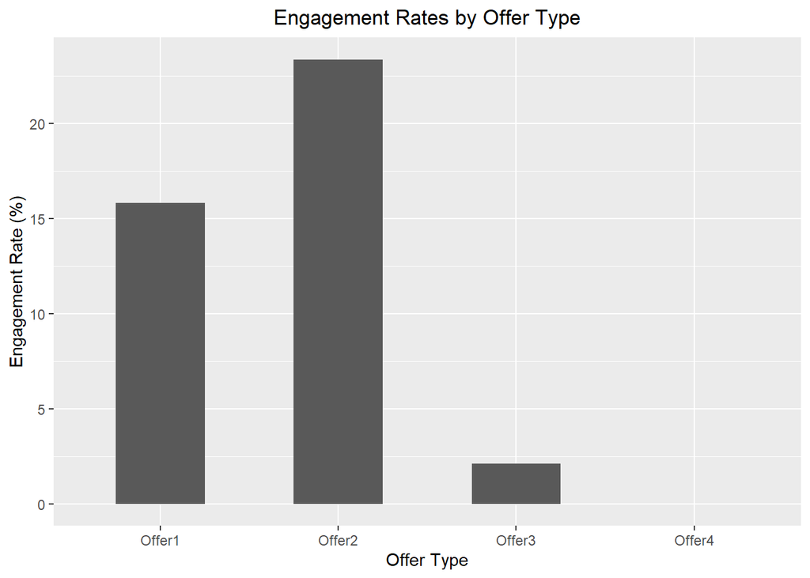

### Engagement Rates By Offer Type and Vehicle Class

Whether there is any noticeable difference in the response rates for each offer type for customers with different vehicle class.

| Renew.Offer.Type | Vehicle.Class | NumEngaged | Count | EngagementRate |
| --- | --- | --- | --- | --- |
| Offer1 | Four-Door Car | 264 | 3752 | 7.0362473 |
| Offer1 | Luxury Car | 6 | 3752 | 0.1599147 |
| Offer1 | Luxury SUV | 18 | 3752 | 0.4797441 |
| Offer1 | Sports Car | 42 | 3752 | 1.1194030 |
| Offer1 | SUV | 168 | 3752 | 4.4776119 |
| Offer1 | Two-Door Car | 96 | 3752 | 2.5586354 |
| Offer2 | Four-Door Car | 336 | 2926 | 11.4832536 |
| Offer2 | Luxury Car | 6 | 2926 | 0.2050581 |
| Offer2 | Luxury SUV | 12 | 2926 | 0.4101162 |
| Offer2 | Sports Car | 48 | 2926 | 1.6404648 |
| Offer2 | SUV | 120 | 2926 | 4.1011620 |
| Offer2 | Two-Door Car | 162 | 2926 | 5.5365687 |
| Offer3 | Four-Door Car | 24 | 1432 | 1.6759777 |
| Offer3 | Luxury Car | 0 | 1432 | 0.0000000 |
| Offer3 | Luxury SUV | 0 | 1432 | 0.0000000 |
| Offer3 | Sports Car | 0 | 1432 | 0.0000000 |
| Offer3 | SUV | 0 | 1432 | 0.0000000 |
| Offer3 | Two-Door Car | 6 | 1432 | 0.4189944 |
| Offer4 | Four-Door Car | 0 | 1024 | 0.0000000 |
| Offer4 | Luxury Car | 0 | 1024 | 0.0000000 |
| Offer4 | Luxury SUV | 0 | 1024 | 0.0000000 |
| Offer4 | Sports Car | 0 | 1024 | 0.0000000 |
| Offer4 | SUV | 0 | 1024 | 0.0000000 |
| Offer4 | Two-Door Car | 0 | 1024 | 0.0000000 |

Customers with *Four-Door Car* respond the most frequently for all offer types. However, customers with *SUV* respond with a higher chance to *Offer1* than to *Offer2*. If we see any significant difference in the response rates among different customer segments, we can fine-tune who to target for different set of offers. If we believe customers with *SUV* respond to *Offer1* with a significantly higher chance than to *Offer2*, then we can target *SUV* customers with *Offer1*. On the other hand, if we believe customers with *Two-Door Car* respond to *Offer2* with a significantly higher chance than to other offer types, then we can target *Two-Door Car* owners with *Offer2*.

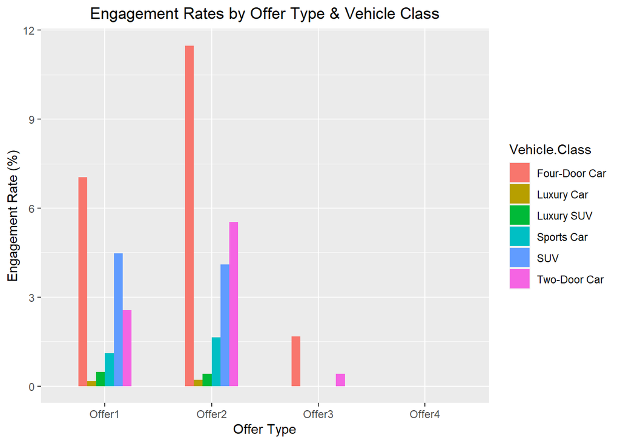

### Engagement Rates By Sales channel

| Sales.Channel | Count | NumEngaged | EngagementRate |
| --- | --- | --- | --- |
| Agent | 3477 | 666 | 19.15444 |
| Branch | 2567 | 294 | 11.45306 |
| Call Center | 1765 | 192 | 10.87819 |
| Web | 1325 | 156 | 11.77358 |

*Agent* works best in terms of getting responses from the customers. Then, sales through *Web* works the second best.

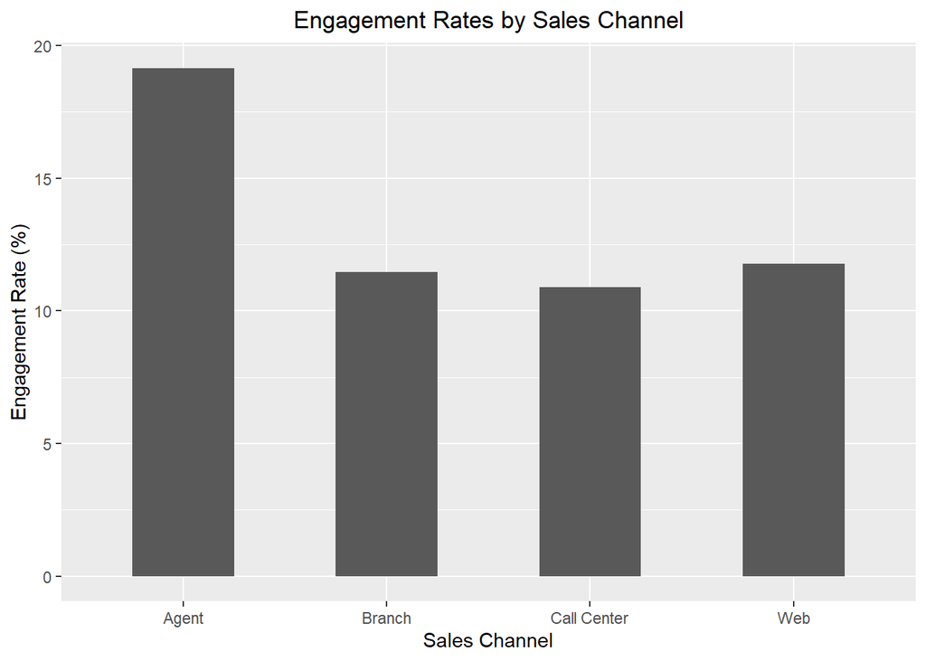

### Engagement Rates By Sales Channel And Vehicle Size

| Sales.Channel | Vehicle.Size | NumEngaged | Count | EngagementRate |
| --- | --- | --- | --- | --- |
| Agent | Large | 72 | 3477 | 2.0707506 |
| Agent | Medsize | 504 | 3477 | 14.4952545 |
| Agent | Small | 90 | 3477 | 2.5884383 |
| Branch | Large | 54 | 2567 | 2.1036229 |
| Branch | Medsize | 192 | 2567 | 7.4795481 |
| Branch | Small | 48 | 2567 | 1.8698870 |
| Call Center | Large | 24 | 1765 | 1.3597734 |
| Call Center | Medsize | 120 | 1765 | 6.7988669 |
| Call Center | Small | 48 | 1765 | 2.7195467 |
| Web | Large | 18 | 1325 | 1.3584906 |
| Web | Medsize | 126 | 1325 | 9.5094340 |
| Web | Small | 12 | 1325 | 0.9056604 |

Customers with *Medsize* vehicles respond best to all sales channels. The engagement rates across different sales channels differ slightly between *Large* and *Small* vehicle owners. For example, *Small* vehicle owners respond better through *Agent* and *Call Center* channels, while on the other hand, *Large* vehicle owners respond better through the *Branch* and *Web* channels.

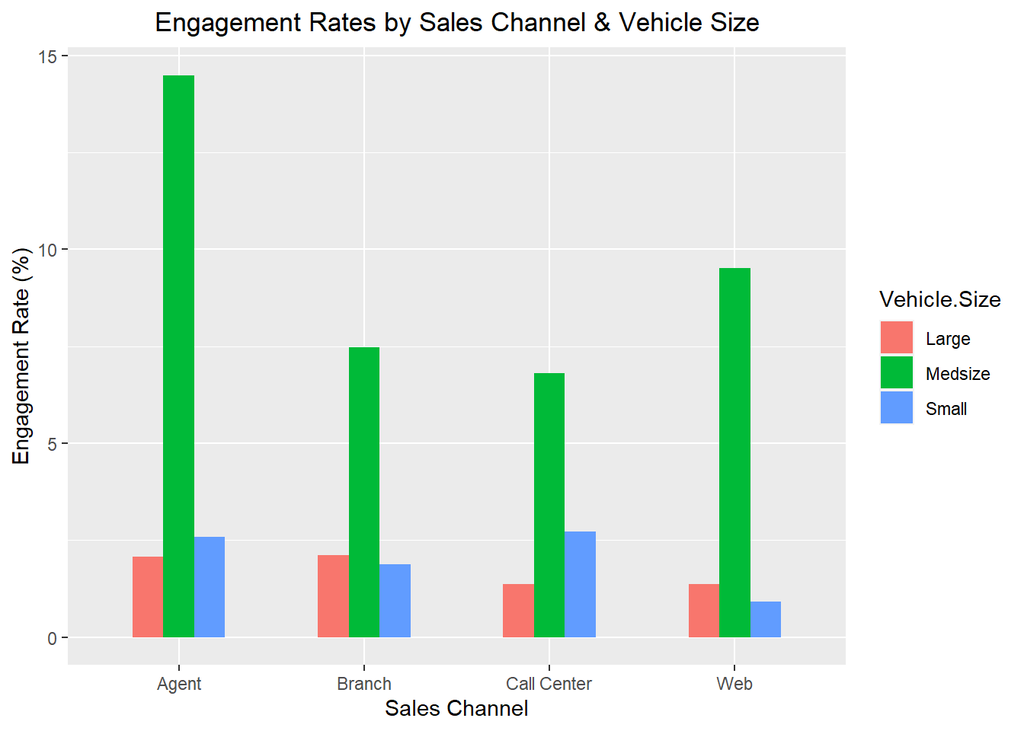

```r
ggplot(engagementRateBySalesChannelVehicleSize, aes(x=Sales.Channel, y=EngagementRate, fill=Vehicle.Size)) +
  geom_bar(width = 0.5, stat="identity", position="dodge") +
  ggtitle("Engagement Rates by Sales Channel & Vehicle Size") +
  xlab("Sales Channel") +
  ylab("Engagement Rate (%)") +
  theme(plot.title = element_text(hjust = 0.5))
```

### Engagement Rates by Months Since Policy Inception

| Months.Since.Policy.Inception | Count | NumEngaged | EngagementRate |
| --- | --- | --- | --- |
| 59 | 142 | 48 | 33.80282 |
| 56 | 112 | 36 | 32.14286 |
| 43 | 109 | 30 | 27.52294 |
| 93 | 90 | 24 | 26.66667 |
| 3 | 114 | 30 | 26.31579 |
| 54 | 93 | 24 | 25.80645 |

Most of the Engagement Rate in Months Since Policy Inception are between 40 to 60.

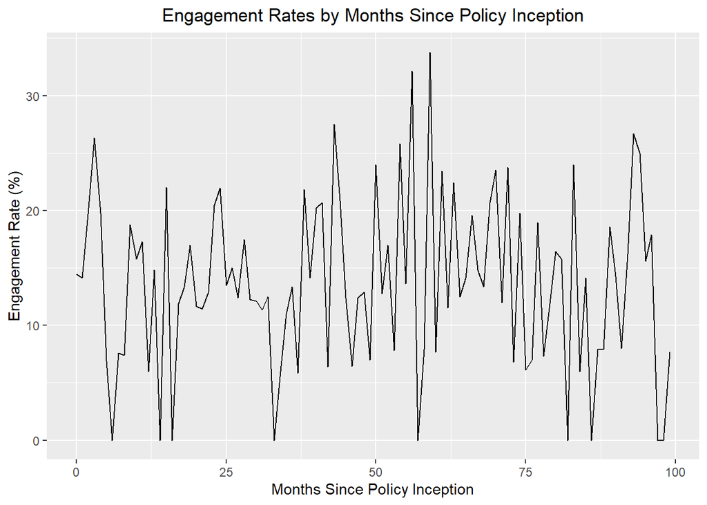

## Segmenting Customer Base

Segmenting our customer base by *Customer.Lifetime.Value* and *Months.Since.Policy.Inception*.

### Customer Lifetime Value Summary

```
##    Min. 1st Qu.  Median    Mean 3rd Qu.    Max.
##    1898    3994    5780    8005    8962   83325
```

### Months Since Policy Inception Summary

```
##    Min. 1st Qu.  Median    Mean 3rd Qu.    Max.
##    0.00   24.00   48.00   48.06   71.00   99.00
```

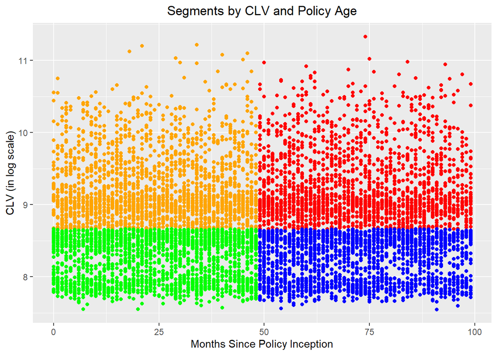

The data points in red represent those customers in the High CLV and High Policy Age segment. Those in orange represent the High CLV and Low Policy Age group, those in blue represent the Low CLV and High Policy Age group, and lastly, those in green represent the Low CLV and Low Policy Age group.

| CLV.Segment | Policy.Age.Segment | Count | NumEngaged | EngagementRate |
| --- | --- | --- | --- | --- |
| High | High | 2249 | 312 | 13.87283 |
| High | Low | 2317 | 306 | 13.20673 |
| Low | High | 2253 | 366 | 16.24501 |
| Low | Low | 2315 | 324 | 13.99568 |

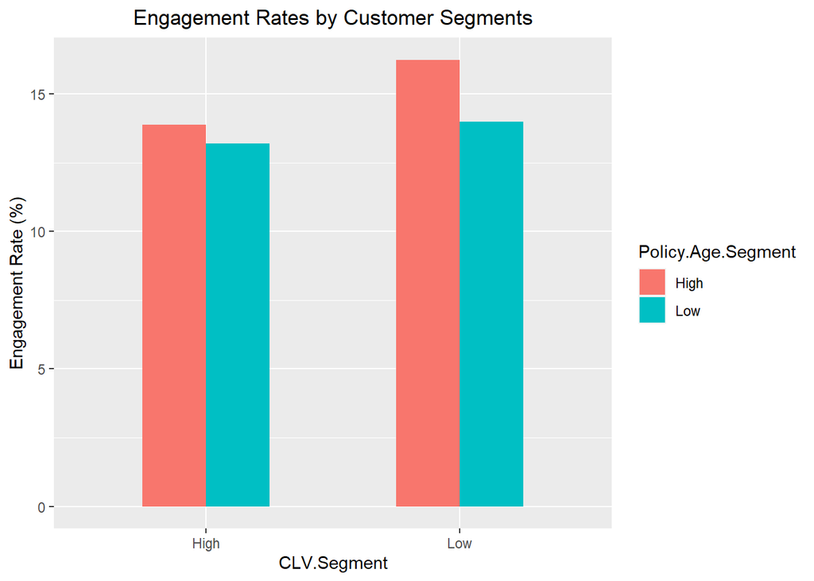

*High Policy.Age.Segment* has a higher engagement than *Low Policy.Age.Segment*. This suggests that those customers who have been insured by this company longer respond better. It is also noticeable that the *High Policy Age* and *Low CLV* segment has the highest engagement rate among the four segments.

## Variable Encoding

Overall engagement rate looks.

```
## [1] 0.1432012
```

### Categorical Variable Encoding

| Sales.ChannelAgent | Sales.ChannelBranch | Sales.ChannelCall Center | Sales.ChannelWeb | Vehicle.SizeMedsize | Vehicle.SizeSmall | Vehicle.ClassLuxury Car | Vehicle.ClassLuxury SUV | Vehicle.ClassSports Car | Vehicle.ClassSUV | Vehicle.ClassTwo-Door Car | PolicyCorporate L2 | PolicyCorporate L3 | PolicyPersonal L1 | PolicyPersonal L2 | PolicyPersonal L3 | PolicySpecial L1 | PolicySpecial L2 | PolicySpecial L3 | Policy.TypePersonal Auto | Policy.TypeSpecial Auto | EmploymentStatusEmployed | EmploymentStatusMedical Leave | EmploymentStatusRetired | EmploymentStatusUnemployed | Marital.StatusMarried | Marital.StatusSingle | EducationCollege | EducationDoctor | EducationHigh School or Below | … |
| --- | --- | --- | --- | --- | --- | --- | --- | --- | --- | --- | --- | --- | --- | --- | --- | --- | --- | --- | --- | --- | --- | --- | --- | --- | --- | --- | --- | --- | --- | --- |
| 1 | 0 | 0 | 0 | 1 | 0 | 0 | 0 | 0 | 0 | 1 | 0 | 1 | 0 | 0 | 0 | 0 | 0 | 0 | 0 | 0 | 1 | 0 | 0 | 0 | 1 | 0 | 0 | 0 | 0 | … |
| 1 | 0 | 0 | 0 | 1 | 0 | 0 | 0 | 0 | 0 | 0 | 0 | 0 | 0 | 0 | 1 | 0 | 0 | 0 | 1 | 0 | 0 | 0 | 0 | 1 | 0 | 1 | 0 | 0 | 0 | … |
| 1 | 0 | 0 | 0 | 1 | 0 | 0 | 0 | 0 | 0 | 1 | 0 | 0 | 0 | 0 | 1 | 0 | 0 | 0 | 1 | 0 | 1 | 0 | 0 | 0 | 1 | 0 | 0 | 0 | 0 | … |
| 0 | 0 | 1 | 0 | 1 | 0 | 0 | 0 | 0 | 1 | 0 | 1 | 0 | 0 | 0 | 0 | 0 | 0 | 0 | 0 | 0 | 0 | 0 | 0 | 1 | 1 | 0 | 0 | 0 | 0 | … |
| 1 | 0 | 0 | 0 | 1 | 0 | 0 | 0 | 0 | 0 | 0 | 0 | 0 | 1 | 0 | 0 | 0 | 0 | 0 | 1 | 0 | 1 | 0 | 0 | 0 | 0 | 1 | 0 | 0 | 0 | … |
| 0 | 0 | 0 | 1 | 1 | 0 | 0 | 0 | 0 | 0 | 1 | 0 | 0 | 0 | 0 | 1 | 0 | 0 | 0 | 1 | 0 | 1 | 0 | 0 | 0 | 1 | 0 | 0 | 0 | 0 | … |

### Continuous Features

| Sales.ChannelAgent | Sales.ChannelBranch | Sales.ChannelCall Center | Sales.ChannelWeb | Vehicle.SizeMedsize | Vehicle.SizeSmall | Vehicle.ClassLuxury Car | Vehicle.ClassLuxury SUV | Vehicle.ClassSports Car | Vehicle.ClassSUV | Vehicle.ClassTwo-Door Car | PolicyCorporate L2 | PolicyCorporate L3 | PolicyPersonal L1 | PolicyPersonal L2 | PolicyPersonal L3 | PolicySpecial L1 | PolicySpecial L2 | PolicySpecial L3 | Policy.TypePersonal Auto | Policy.TypeSpecial Auto | EmploymentStatusEmployed | EmploymentStatusMedical Leave | EmploymentStatusRetired | EmploymentStatusUnemployed | Marital.StatusMarried | Marital.StatusSingle | EducationCollege | EducationDoctor | EducationHigh School or Below | … |
| --- | --- | --- | --- | --- | --- | --- | --- | --- | --- | --- | --- | --- | --- | --- | --- | --- | --- | --- | --- | --- | --- | --- | --- | --- | --- | --- | --- | --- | --- | --- |
| 1 | 0 | 0 | 0 | 1 | 0 | 0 | 0 | 0 | 0 | 1 | 0 | 1 | 0 | 0 | 0 | 0 | 0 | 0 | 0 | 0 | 1 | 0 | 0 | 0 | 1 | 0 | 0 | 0 | 0 | … |
| 1 | 0 | 0 | 0 | 1 | 0 | 0 | 0 | 0 | 0 | 0 | 0 | 0 | 0 | 0 | 1 | 0 | 0 | 0 | 1 | 0 | 0 | 0 | 0 | 1 | 0 | 1 | 0 | 0 | 0 | … |
| 1 | 0 | 0 | 0 | 1 | 0 | 0 | 0 | 0 | 0 | 1 | 0 | 0 | 0 | 0 | 1 | 0 | 0 | 0 | 1 | 0 | 1 | 0 | 0 | 0 | 1 | 0 | 0 | 0 | 0 | … |
| 0 | 0 | 1 | 0 | 1 | 0 | 0 | 0 | 0 | 1 | 0 | 1 | 0 | 0 | 0 | 0 | 0 | 0 | 0 | 0 | 0 | 0 | 0 | 0 | 1 | 1 | 0 | 0 | 0 | 0 | … |
| 1 | 0 | 0 | 0 | 1 | 0 | 0 | 0 | 0 | 0 | 0 | 0 | 0 | 1 | 0 | 0 | 0 | 0 | 0 | 1 | 0 | 1 | 0 | 0 | 0 | 0 | 1 | 0 | 0 | 0 | … |
| 0 | 0 | 0 | 1 | 1 | 0 | 0 | 0 | 0 | 0 | 1 | 0 | 0 | 0 | 0 | 1 | 0 | 0 | 0 | 1 | 0 | 1 | 0 | 0 | 0 | 1 | 0 | 0 | 0 | 0 | … |

## Building Predictive Models

### Training and Testing Split

#### Dimensions of DataFrame

```
## [1] 9134   42
```

#### Dimensions of Training Set

```
## [1] 6393   42
```

#### Dimensions of Testing Set

```
## [1] 2741   42
```

### Training a Random Forest Model

| left daughter | right daughter | split var | split point | status | prediction |
| --- | --- | --- | --- | --- | --- |
| 2 | 3 | 1 | 0.500 | 1 | 0 |
| 4 | 5 | 36 | 11900.000 | 1 | 0 |
| 6 | 7 | 41 | 1.500 | 1 | 0 |
| 8 | 9 | 39 | 56.500 | 1 | 0 |
| 10 | 11 | 24 | 0.500 | 1 | 0 |
| 12 | 13 | 32 | 0.500 | 1 | 0 |
| 14 | 15 | 23 | 0.500 | 1 | 0 |
| 16 | 17 | 9 | 0.500 | 1 | 0 |
| 18 | 19 | 38 | 6.500 | 1 | 0 |
| 20 | 21 | 26 | 0.500 | 1 | 0 |
| 22 | 23 | 39 | 77.000 | 1 | 0 |
| 24 | 25 | 22 | 0.500 | 1 | 0 |
| 26 | 27 | 34 | 0.500 | 1 | 0 |
| 28 | 29 | 17 | 0.500 | 1 | 0 |
| 30 | 31 | 38 | 12.500 | 1 | 0 |
| 32 | 33 | 35 | 2045.481 | 1 | 0 |
| 34 | 35 | 12 | 0.500 | 1 | 0 |
| 36 | 37 | 32 | 0.500 | 1 | 0 |
| 38 | 39 | 27 | 0.500 | 1 | 0 |
| 40 | 41 | 36 | 17222.000 | 1 | 0 |
| 42 | 43 | 40 | 1.500 | 1 | 0 |
| 44 | 45 | 6 | 0.500 | 1 | 0 |
| 46 | 47 | 28 | 0.500 | 1 | 0 |
| 0 | 0 | 0 | 0.000 | -1 | 1 |
| 0 | 0 | 0 | 0.000 | -1 | 1 |
| 0 | 0 | 0 | 0.000 | -1 | 1 |
| 0 | 0 | 0 | 0.000 | -1 | 1 |
| 0 | 0 | 0 | 0.000 | -1 | 1 |
| 0 | 0 | 0 | 0.000 | -1 | 1 |
| 0 | 0 | 0 | 0.000 | -1 | 1 |
| 0 | 0 | 0 | 0.000 | -1 | 1 |
| 0 | 0 | 0 | 0.000 | -1 | 2 |
| 0 | 0 | 0 | 0.000 | -1 | 1 |
| 0 | 0 | 0 | 0.000 | -1 | 1 |
| 0 | 0 | 0 | 0.000 | -1 | 2 |
| 0 | 0 | 0 | 0.000 | -1 | 1 |
| 0 | 0 | 0 | 0.000 | -1 | 1 |
| 0 | 0 | 0 | 0.000 | -1 | 1 |
| 0 | 0 | 0 | 0.000 | -1 | 1 |
| 0 | 0 | 0 | 0.000 | -1 | 1 |
| 0 | 0 | 0 | 0.000 | -1 | 1 |
| 0 | 0 | 0 | 0.000 | -1 | 1 |
| 0 | 0 | 0 | 0.000 | -1 | 1 |
| 0 | 0 | 0 | 0.000 | -1 | 2 |
| 0 | 0 | 0 | 0.000 | -1 | 1 |
| 0 | 0 | 0 | 0.000 | -1 | 2 |
| 0 | 0 | 0 | 0.000 | -1 | 1 |

**Note:** Looking at the information about the first tree in the forest. This gives us some information about the structure of the tree. The left daughter and right daughter columns tell us the location of this node in the given tree. The status column tells us whether the node is terminal (-1) or not (1). The prediction column tells us the prediction from this node.

With the trained model we can understand the importance or the impact of each feature on the final predictions.

```
##                               MeanDecreaseGini
## Sales.ChannelAgent                   8.6034377
## Sales.ChannelBranch                  1.1993601
## Sales.ChannelCall Center             2.0732142
## Sales.ChannelWeb                     1.0330222
## Vehicle.SizeMedsize                  1.4544208
## Vehicle.SizeSmall                    1.5875017
## Vehicle.ClassLuxury Car              0.1169035
## Vehicle.ClassLuxury SUV              0.3680741
## Vehicle.ClassSports Car              0.8258549
## Vehicle.ClassSUV                     0.6650559
## Vehicle.ClassTwo-Door Car            0.6003396
## PolicyCorporate L2                   0.2825866
## PolicyCorporate L3                   0.2479982
## PolicyPersonal L1                    0.3635968
## PolicyPersonal L2                    0.2552813
## PolicyPersonal L3                    0.3187256
## PolicySpecial L1                     0.4215858
## PolicySpecial L2                     0.1821766
## PolicySpecial L3                     0.3510348
## Policy.TypePersonal Auto             0.2885951
## Policy.TypeSpecial Auto              0.3559702
## EmploymentStatusEmployed             5.2959641
## EmploymentStatusMedical Leave        0.7683404
## EmploymentStatusRetired             72.3287169
## EmploymentStatusUnemployed           6.3712960
## Marital.StatusMarried                4.3567028
## Marital.StatusSingle                 3.2262618
## EducationCollege                     0.9239188
## EducationDoctor                      0.3772922
## EducationHigh School or Below        0.7793498
## EducationMaster                      1.3554245
## CoverageExtended                     0.7816077
## CoveragePremium                      0.7465441
## GenderM                              0.7899367
## Customer.Lifetime.Value             11.5381082
## Income                              16.5539771
## Monthly.Premium.Auto                 8.8515763
## Months.Since.Last.Claim              5.8485320
## Months.Since.Policy.Inception        9.1610989
## Number.of.Open.Complaints            2.2196808
## Number.of.Policies                   3.3621803
## Total.Claim.Amount                  16.7594462
```

The **EmploymentStatusRetired** feature seems to be the most important factor in making the final prediction and the **Income, Total.Claim.Amount, and Customer.Lifetime.Value** features follow as the important features.

### Evaluations

```
## [1] "Train Accuracy: 0.8720"
```

```
## [1] "Test Accuracy: 0.8745"
```

```
## [1] "Train Precision: 0.9914"
```

```
## [1] "Test Precision: 0.9706"
```

```
## [1] "Train Recall: 0.1234"
```

```
## [1] "Test Recall: 0.0878"
```

```
## integer(0)
```

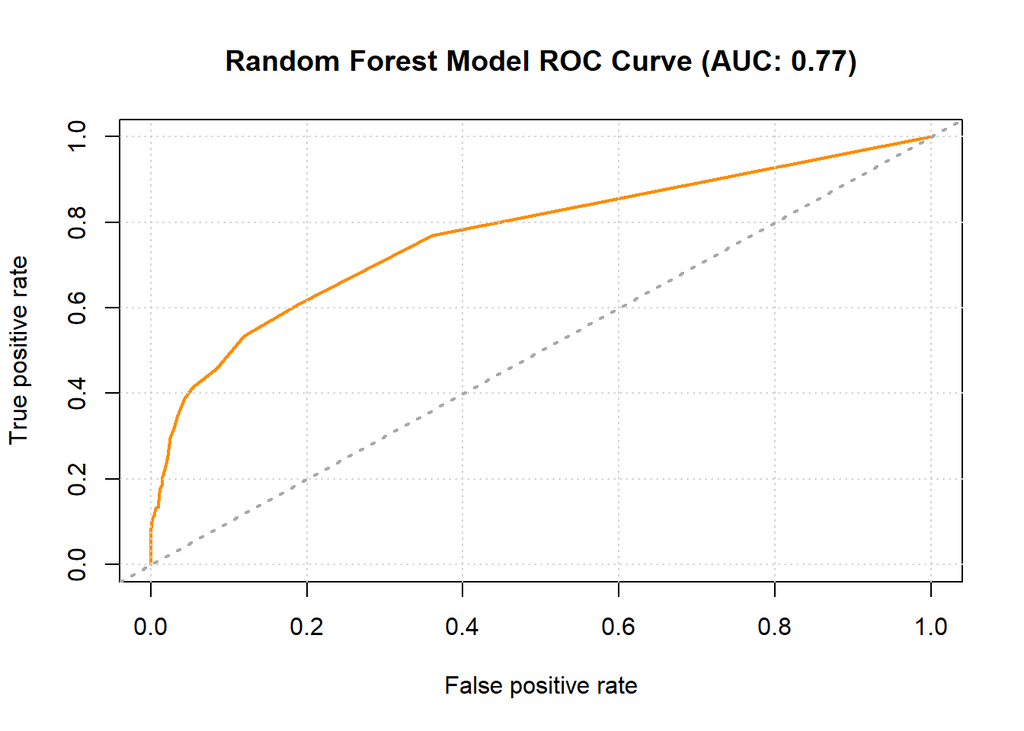

According to the plot, The AUC of our Random Forest Model was 0.77.Compared to the benchmark straight line, which represents the random line(chance), the model performs much better, this shows that the model predictions are much better than random predictions.